# climate change and urban planning

Shuhan Song

12/3/2019

#### Statistical Model for estimation of flood risk in NYC

**Assumptions**

- local sea level is affected only by tidal variations, storm surge, and changes to the long-term mean.
- use different fixed values of the tide level and storm surge
- all other sea level variations follow a normal (Gaussian distribution)

**Key variables** (meter)

current corrent normal sea level = 0

1. tidal variations
   - zero point is halfway between the high and low tide level
   - ranges from -1.25 to 1.25 m
   - use high tide level 1.25m and high tide level -1.25 m to model flood risks
2. storm surge
   - 1 m
   - 2 m
   - 3 m
3. changes to the long-term mean in 2050, which is caused by climate change (combining RCP 4.5 and RCP 8.5)
   - Based on the report by New York City Panel on Climate Change (NPCC) which predicted RCP 4.5 and RCP 8.5 scenarios in 2050s
   - low estimate (10th percentile): 7 inches
   - middle estimate (25-75th percentile): 11-24 inches
   - high estimate (90th percentile): 31 inches
4. background variations
   - normally distributed with mean = 0 and stdv = 3

**Criteria for Flood event**

Total sea level anomaly greater than 5m.

Total sea level anomaly = tide + storm surge + climate variability (background + climate change)

#### Model the model!

```r
library(tidyverse)
library(kableExtra)
library(here)
```

```r
# set up the variables
tide_level <- c(-1.25, 1.25)

storm_surge <- c(0, 1, 2, 3)

mean_2050 <- c(7, 11, 24, 31) * 0.0254 # conversion from inches to meters
```

#### Current condition:

```r
sea_level_cur <- 1
tide_level_cur <- 1
storm_surge_cur <- 1
true_mean_cur <- 1
n <- 5000
m <- 1

for (j in 1:length(storm_surge)) {
  for(t in 1:length(tide_level)){
    for (i in 1:n){
      sea_level_cur[m] <- storm_surge[j] + tide_level[t] + rnorm(1, mean = 0 , sd = 3)
      tide_level_cur[m] <- tide_level[t]
      storm_surge_cur[m] <- storm_surge[j]
      true_mean_cur[m] <- storm_surge[j] + tide_level[t]
      m = m+1
      }
    }
  }

flood_cur <- data_frame(tide_level_cur, storm_surge_cur, sea_level_cur, true_mean_cur)
```

```r
# test the model
test_cur <- flood_cur %>%
  group_by(tide_level_cur, storm_surge_cur) %>%
  summarize(mean = mean(sea_level_cur),
            true_mean = mean(true_mean_cur)
            )

kable(test_cur,
      col.names = c("tide level", "storm surge", "mean", "true mean")) %>%
  kable_styling(bootstrap_options = "striped")
```

| tide level | storm surge | mean | true mean |
| --- | --- | --- | --- |
| -1.25 | 0 | -1.2549846 | -1.25 |
| -1.25 | 1 | -0.2001538 | -0.25 |
| -1.25 | 2 | 0.7821218 | 0.75 |
| -1.25 | 3 | 1.7269403 | 1.75 |
| 1.25 | 0 | 1.1887730 | 1.25 |
| 1.25 | 1 | 2.3287822 | 2.25 |
| 1.25 | 2 | 3.2854425 | 3.25 |
| 1.25 | 3 | 4.2474644 | 4.25 |

```r
# flood risk
cur_flood_risk <- flood_cur %>%
  filter(sea_level_cur > 5) %>%
  group_by(tide_level_cur, storm_surge_cur) %>%
  summarize(flood_risk_cur = n()/n,
            true_mean = mean(true_mean_cur))

kable(cur_flood_risk,
      col.names = c("tide level", "storm surge", "flood risk", "true mean")) %>%
  kable_styling(bootstrap_options = "striped")
```

| tide level | storm surge | flood risk | true mean |
| --- | --- | --- | --- |
| -1.25 | 0 | 0.0168 | -1.25 |
| -1.25 | 1 | 0.0396 | -0.25 |
| -1.25 | 2 | 0.0804 | 0.75 |
| -1.25 | 3 | 0.1454 | 1.75 |
| 1.25 | 0 | 0.1050 | 1.25 |
| 1.25 | 1 | 0.1810 | 2.25 |
| 1.25 | 2 | 0.2828 | 3.25 |
| 1.25 | 3 | 0.4026 | 4.25 |

- The risk of flooding under normal conditions:
  - low tide: 1.68% of flood risk
  - high tide: 10.5% of flood risk
- The risk of flooding with storm surge:
  - 1m:
    - low tide: 3.96% of flood risk
    - high tide: 18.1% of flood risk
  - 2m:
    - low tide: 8.04% of flood risk
    - high tide: 28.28% of flood risk
  - 3m:
    - low tide: 14.54% of flood risk
    - high tide: 40.26% of flood risk

**visualize the flood risk**

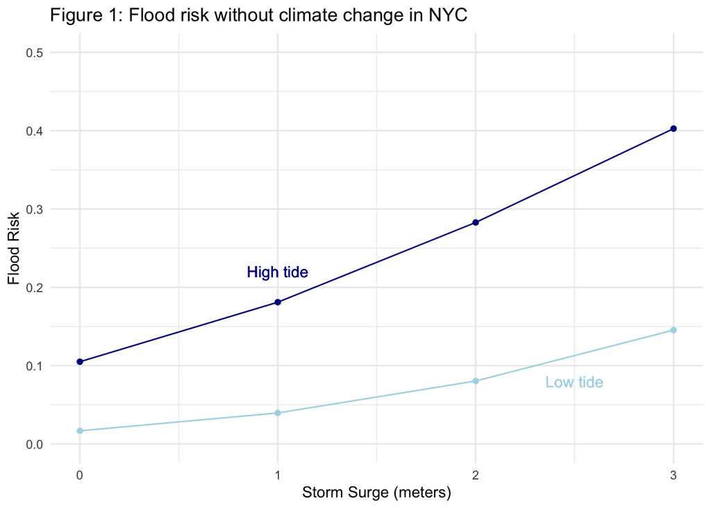

```r
risk_high_cur <- cur_flood_risk %>%
  filter(tide_level_cur == 1.25)
risk_low_cur <- cur_flood_risk %>%
  filter(tide_level_cur == -1.25)

risk_range_cur <- data_frame("storm_surge_cur" = risk_high_cur$storm_surge_cur,
                             "high_tide_risk" = risk_high_cur$flood_risk_cur,
                             "low_tide_risk" = risk_low_cur$flood_risk_cur)

ggplot(data = risk_range_cur,
       aes(x = storm_surge_cur)) +
  geom_point(aes(y = high_tide_risk),
             color = "darkblue") +
  geom_point(aes(y = low_tide_risk),
             color = "lightblue") +
  geom_line(aes(y = high_tide_risk),
             color = "darkblue") +
  geom_line(aes(y = low_tide_risk),
             color = "lightblue") +
  labs(x = "Storm Surge (meters)",
       y = "Flood Risk",
       title = "Figure 1: Flood risk without climate change in NYC") +
  geom_text(x = 2.5, y = 0.08,
            label = "Low tide",
            color = "lightblue") +
  geom_text(x = 1, y = 0.22,
            label = "High tide",
            color = "darkblue") +
  scale_y_continuous(limits = c(0, 0.5)) +
  theme_minimal()
```

```r
ggsave(here::here("Current flood risk.jpg"), width = 4, height = 3)
```

#### Climate change in 2050

```r
sea_level_2050 <- 1
tide_level_2050 <- 1
storm_surge_2050 <- 1
mean_sea_level_2050 <- 1
true_mean_2050 <- 1
n <- 5000
m <- 1
for (k in 1:length(mean_2050)) {
  for (j in 1:length(storm_surge)) {
    for(t in 1:length(tide_level)){
      for (i in 1:n){
        sea_level_2050[m] <- storm_surge[j] + tide_level[t] + rnorm(1, mean = mean_2050[k] , sd = 3)
        tide_level_2050[m] <- tide_level[t]
        storm_surge_2050[m] <- storm_surge[j]
        mean_sea_level_2050[m] <- mean_2050[k]
        true_mean_2050[m] <- storm_surge[j] + tide_level[t] + mean_2050[k]
        m = m+1
        }
      }
    }
  }

flood_2050 <- data_frame(mean_sea_level_2050, tide_level_2050, storm_surge_2050, sea_level_2050, true_mean_2050)
```

```r
# test the model
test_2050 <- flood_2050 %>%
  group_by(mean_sea_level_2050, tide_level_2050, storm_surge_2050) %>%
  summarize(mean = mean(sea_level_2050),
            true_mean = mean(true_mean_2050)
            )
kable(test_2050,
      col.names = c("mean sea leve", "tide level", "storm surge", "mean", "true mean")) %>%
  kable_styling(bootstrap_options = "striped")
```

| mean sea leve | tide level | storm surge | mean | true mean |
| --- | --- | --- | --- | --- |
| 0.1778 | -1.25 | 0 | -1.0727344 | -1.0722 |
| 0.1778 | -1.25 | 1 | -0.1074957 | -0.0722 |
| 0.1778 | -1.25 | 2 | 0.9580275 | 0.9278 |
| 0.1778 | -1.25 | 3 | 1.9136722 | 1.9278 |
| 0.1778 | 1.25 | 0 | 1.4110876 | 1.4278 |
| 0.1778 | 1.25 | 1 | 2.4028548 | 2.4278 |
| 0.1778 | 1.25 | 2 | 3.4530333 | 3.4278 |
| 0.1778 | 1.25 | 3 | 4.5256031 | 4.4278 |
| 0.2794 | -1.25 | 0 | -0.9654753 | -0.9706 |
| 0.2794 | -1.25 | 1 | 0.0609876 | 0.0294 |
| 0.2794 | -1.25 | 2 | 1.1166428 | 1.0294 |
| 0.2794 | -1.25 | 3 | 1.9982256 | 2.0294 |
| 0.2794 | 1.25 | 0 | 1.5295903 | 1.5294 |
| 0.2794 | 1.25 | 1 | 2.5997783 | 2.5294 |
| 0.2794 | 1.25 | 2 | 3.5411636 | 3.5294 |
| 0.2794 | 1.25 | 3 | 4.4614842 | 4.5294 |
| 0.6096 | -1.25 | 0 | -0.6063853 | -0.6404 |
| 0.6096 | -1.25 | 1 | 0.3908678 | 0.3596 |
| 0.6096 | -1.25 | 2 | 1.3279130 | 1.3596 |
| 0.6096 | -1.25 | 3 | 2.3889178 | 2.3596 |
| 0.6096 | 1.25 | 0 | 1.8792882 | 1.8596 |
| 0.6096 | 1.25 | 1 | 2.8774406 | 2.8596 |
| 0.6096 | 1.25 | 2 | 3.8758832 | 3.8596 |
| 0.6096 | 1.25 | 3 | 4.8523465 | 4.8596 |
| 0.7874 | -1.25 | 0 | -0.4269669 | -0.4626 |
| 0.7874 | -1.25 | 1 | 0.5839194 | 0.5374 |
| 0.7874 | -1.25 | 2 | 1.5673114 | 1.5374 |
| 0.7874 | -1.25 | 3 | 2.5177570 | 2.5374 |
| 0.7874 | 1.25 | 0 | 2.0379826 | 2.0374 |
| 0.7874 | 1.25 | 1 | 2.9980708 | 3.0374 |
| 0.7874 | 1.25 | 2 | 3.9651295 | 4.0374 |
| 0.7874 | 1.25 | 3 | 5.0904075 | 5.0374 |

```r
# flood risk
flood_risk_2050 <- flood_2050 %>%
  filter(sea_level_2050 > 5) %>%
  group_by(mean_sea_level_2050, tide_level_2050, storm_surge_2050) %>%
  summarize(flood_risk = n()/n,
            true_mean = mean(true_mean_2050))

kable(flood_risk_2050,
      col.names = c("mean sea leve", "tide level", "storm surge", "flood risk", "true mean")) %>%
  kable_styling(bootstrap_options = "striped")
```

| mean sea leve | tide level | storm surge | flood risk | true mean |
| --- | --- | --- | --- | --- |
| 0.1778 | -1.25 | 0 | 0.0184 | -1.0722 |
| 0.1778 | -1.25 | 1 | 0.0470 | -0.0722 |
| 0.1778 | -1.25 | 2 | 0.0908 | 0.9278 |
| 0.1778 | -1.25 | 3 | 0.1526 | 1.9278 |
| 0.1778 | 1.25 | 0 | 0.1158 | 1.4278 |
| 0.1778 | 1.25 | 1 | 0.1954 | 2.4278 |
| 0.1778 | 1.25 | 2 | 0.3046 | 3.4278 |
| 0.1778 | 1.25 | 3 | 0.4340 | 4.4278 |
| 0.2794 | -1.25 | 0 | 0.0238 | -0.9706 |
| 0.2794 | -1.25 | 1 | 0.0550 | 0.0294 |
| 0.2794 | -1.25 | 2 | 0.0992 | 1.0294 |
| 0.2794 | -1.25 | 3 | 0.1574 | 2.0294 |
| 0.2794 | 1.25 | 0 | 0.1236 | 1.5294 |
| 0.2794 | 1.25 | 1 | 0.2160 | 2.5294 |
| 0.2794 | 1.25 | 2 | 0.3170 | 3.5294 |
| 0.2794 | 1.25 | 3 | 0.4288 | 4.5294 |
| 0.6096 | -1.25 | 0 | 0.0296 | -0.6404 |
| 0.6096 | -1.25 | 1 | 0.0622 | 0.3596 |
| 0.6096 | -1.25 | 2 | 0.1134 | 1.3596 |
| 0.6096 | -1.25 | 3 | 0.1988 | 2.3596 |
| 0.6096 | 1.25 | 0 | 0.1566 | 1.8596 |
| 0.6096 | 1.25 | 1 | 0.2378 | 2.8596 |
| 0.6096 | 1.25 | 2 | 0.3534 | 3.8596 |
| 0.6096 | 1.25 | 3 | 0.4832 | 4.8596 |
| 0.7874 | -1.25 | 0 | 0.0364 | -0.4626 |
| 0.7874 | -1.25 | 1 | 0.0708 | 0.5374 |
| 0.7874 | -1.25 | 2 | 0.1322 | 1.5374 |
| 0.7874 | -1.25 | 3 | 0.2060 | 2.5374 |
| 0.7874 | 1.25 | 0 | 0.1550 | 2.0374 |
| 0.7874 | 1.25 | 1 | 0.2536 | 3.0374 |
| 0.7874 | 1.25 | 2 | 0.3662 | 4.0374 |
| 0.7874 | 1.25 | 3 | 0.5140 | 5.0374 |

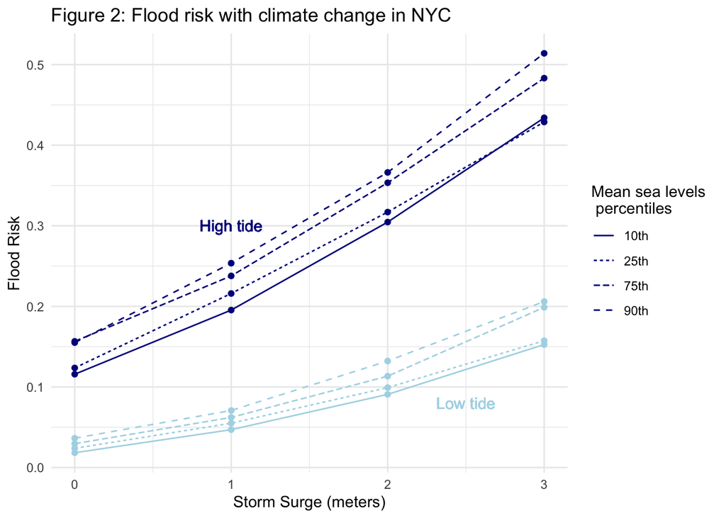

```r
risk_high_2050 <- flood_risk_2050 %>%
  filter(tide_level_2050 == 1.25)
risk_low_2050 <- flood_risk_2050 %>%
  filter(tide_level_2050 == -1.25)

ggplot() +
  geom_point(data = risk_low_2050,
             aes(x = storm_surge_2050,
                 y = flood_risk),
             color = "lightblue") +
  geom_line(data = risk_low_2050,
             aes(x = storm_surge_2050,
                 y = flood_risk,
                 linetype = as.factor(mean_sea_level_2050)),
             color = "lightblue") +
  geom_point(data = risk_high_2050,
             aes(x = storm_surge_2050,
                 y = flood_risk),
             color = "darkblue") +
  geom_line(data = risk_high_2050,
             aes(x = storm_surge_2050,
                 y = flood_risk,
                 linetype = as.factor(mean_sea_level_2050)),
             color = "darkblue") +
  labs(x = "Storm Surge (meters)",
       y = "Flood Risk",
       title = "Figure 2: Flood risk with climate change in NYC") +
  geom_text(data = risk_low_2050,
            x = 2.5, y = 0.08,
            label = "Low tide",
            color = "lightblue") +
  geom_text(data = risk_high_2050,
            x = 1, y = 0.3,
            label = "High tide",
            color = "darkblue") +
  scale_linetype_discrete(name = "Mean sea levels \n percentiles",
                          labels = c("10th", "25th", "75th", "90th")) +
  theme_minimal()
```

```r
ggsave(here::here("Climate change flood risk.jpg"), width = 6, height = 3.6)
```